# Logistic Regression

Assesment Quiz

Andrew Seaman

## 1.

Use an appropriate test to determine if the `birth weight` in ounces of a baby (wt) can be used to predict the probability that the `mother smoked` at all (smoke>0, or, if your Gestation data set has words in the “smoke” column, use smoke!=“never”) during or prior to the pregnancy. The graphic of the correct analysis is shown below.

```r
# a.
ges.glm <- glm( (smoke != "never") ~ wt, data = Gestation, family = binomial)

# b.
summary(ges.glm)
```

```
##
## Call:
## glm(formula = (smoke != "never") ~ wt, family = binomial, data = Gestation)
##
## Coefficients:
##              Estimate Std. Error z value Pr(>|z|)
## (Intercept)  2.416983   0.402280   6.008 1.88e-09 ***
## wt          -0.018277   0.003311  -5.520 3.39e-08 ***
## ---
## Signif. codes:  0 '***' 0.001 '**' 0.01 '*' 0.05 '.' 0.1 ' ' 1
##
## (Dispersion parameter for binomial family taken to be 1)
##
##     Null deviance: 1684.0  on 1225  degrees of freedom
## Residual deviance: 1652.1  on 1224  degrees of freedom
##   (10 observations deleted due to missingness)
## AIC: 1656.1
##
## Number of Fisher Scoring iterations: 4
```

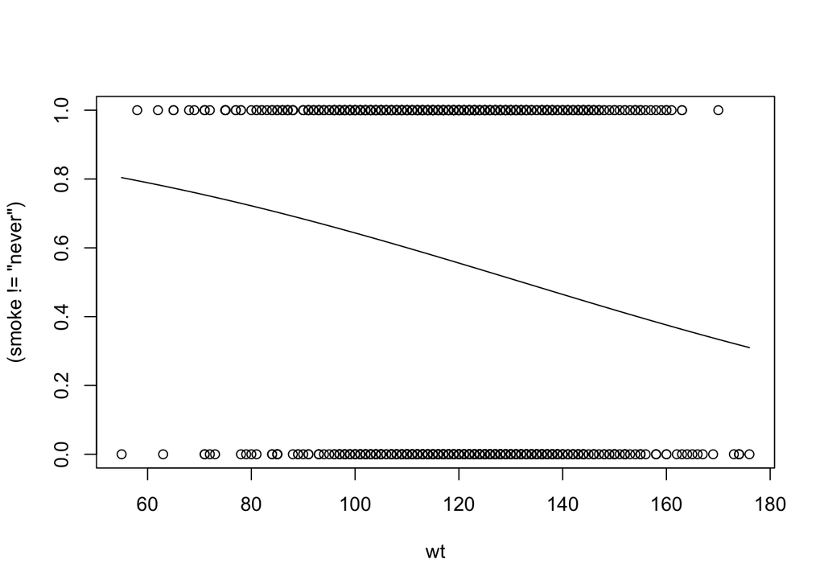

```r
# c.
b <- coef(ges.glm)

# d.
plot( (smoke != "never") ~ wt, data = Gestation)
curve( exp(b[1] + b[2]*x)/(1 + exp(b[1] + b[2]*x)), add=TRUE)
```

> **Answer:**

> ?Gestation

> View(Gestation)

> myglm <- glm(smoke>0 ~ wt, data=Gestation, family=binomial)

> summary(myglm)

Call: glm(formula = smoke > 0 ~ wt, family = binomial, data = Gestation)

## 2.

I wasn’t sure how to do this because I didn’t have the original glm object. However, I knew you could calculate it by hand but wasn’t fast enough to figure out that I had to use the match equation below.

```r
# a.
# COMMENT: I wasn't sure how to do this because I didn't have the original glm object. However, I knew you could calculate it by hand but wasn't fast enough to figure out that I had to use the match equation below.

# > I'm commenting this out because it won't compile otherwise.
# estimated_eb1 <- exp(ges.glm$coefficients["wt"])
# estimated_eb1
```

> **Answer:**

To compute a predicted value we can either do the calculation by hand:

$$P(Y_i = 1|\, x_i) = \frac{e^{\beta_0 + \beta_1 x_i}}{1+e^{\beta_0 +
\beta_1 x_i}} = \pi_i$$

`exp(-6.6035 + 0.3070*25) / (1 + exp(-6.6035 + 0.3070*25)) = 0.7448821`

Or we can use the predict function:

`predict(glmObject, data.frame(mpg=25), type="response")`

However, in this particular case, we don’t have access to the “glmObject” that created the summary output, so we can only compute the answer by hand.

## 3.

I didn’t quite get to this.

> **Answer:**

To intepret the effect of mpg (the x-variable) on the odds, we compute exp(0.3070), which gives the value of eb1 . See the Overview page of Logistic Regression for an explanation.

Coefficients: Estimate Std. Error z value Pr(>|z|)  
(Intercept) -6.6035 2.3514 -2.808 0.00498 mpg 0.3070 0.1148 2.673 0.00751

Since exp(0.3070) = 1.359341, we find that the odds of a success, i.e., that Yi =1 increases by 35.9341%, which rounds to 36% for every 1 unit increase in x.

Notices that the 35.9341 came from 1.359341. If you have 1.36 of what you originally had, then you increased by 0.36 or 36%.